# MSBA ML2 TP2 Team 11

Team 11

Load packages and read files

```r
library(tidyverse)
library(data.table)
library(lubridate)
library(magrittr)
library(Matrix)
library(xgboost)
library(parallel)
library(pls)
library(glmnet)
library(splines)
library(gam)
set.seed(5072)
```

Read file

```r
sales_train <- read.csv("sales_train.csv") # the training set. Daily historical data from January 2013 to October 2015.
test_input <- read.csv("test.csv")
item_categories <- read.csv("item_categories.csv") # supplemental information about the items categories.
items <- read.csv("items.csv") # supplemental information about the items/products.
shops <- read.csv("shops.csv") # supplemental information about the shops.
```

1. Merge Dataset 1.1 Merge train dataset

```r
train <- sales_train %>%
  left_join(items,by = "item_id")

train$item_name <- NULL
```

1.2 Merge test

```r
test <- test_input %>%
  left_join(items, by = "item_id")

test$item_name <- NULL
test$ID <- NULL
test$date_block_num <- 34
```

2. Check data quality 2.1 Check data quality - missing value

```r
colSums(is.na(train))
```

```
##             date   date_block_num          shop_id          item_id
##                0                0                0                0
##       item_price     item_cnt_day item_category_id
##                0                0                0
```

```r
colSums(is.na(test))
```

```
##          shop_id          item_id item_category_id   date_block_num
##                0                0                0                0
```

There are no missing value for both training and testing datasets

2.2 Check data quality - negative value

```r
negative <- filter(train, item_cnt_day < 0 | item_price <= 0)
count(negative)
```

```
## # A tibble: 1 x 1
##       n
##   <int>
## 1  7357
```

```r
train <- filter(train, item_cnt_day >= 0 & item_price > 0)
dim(train)
```

```
## [1] 2928492       7
```

item_cnt_day for some rows is “-1”, which I don’t know wheather it’s caused by typing error or there is special meaning for this “-1”. Considerd the count of all the invalid data is only 7357, which is only 0.25% of total training data.Hence, I decided to delete those invalid data.Now left 2928492 rows of data.

2.3.1 Check data quality - duplicates data in supplemental datasets

```r
shops[duplicated(shops$shop_name),]
```

```
## [1] shop_name shop_id
## <0 rows> (or 0-length row.names)
```

```r
items[duplicated(items$item_name),]
```

```
## [1] item_name        item_id          item_category_id
## <0 rows> (or 0-length row.names)
```

```r
item_categories[duplicated(item_categories$item_category_name),]
```

```
## [1] item_category_name item_category_id
## <0 rows> (or 0-length row.names)
```

There are no duplicates data in “shops”, “items”, and “item_categories” tables which means that for each shop_id, item_id, item_categories_id, they are referring to different shop. item and item’ categories.

2.3.2 Check data quality - duplicates data in training dataset

```r
train[duplicated(train),]
```

```
##               date date_block_num shop_id item_id item_price item_cnt_day
## 76764   05.01.2013              0      54   20130        149            1
## 1431759 23.02.2014             13      50    3423        999            1
## 1492996 23.03.2014             14      21    3423        999            1
## 1667713 01.05.2014             16      50    3423        999            1
## 1861712 12.07.2014             18      25    3423        999            1
## 2193121 31.12.2014             23      42   21619        499            1
##         item_category_id
## 76764                 40
## 1431759               23
## 1492996               23
## 1667713               23
## 1861712               23
## 2193121               37
```

```r
train <- train[!duplicated(train),]
```

However, there are 6 duplicated rows in training dataset. Therefore I deleted these duplicated rows.

3. Data Preprocessing 3.1 Create dates column

```r
train$date <- dmy(train$date)
train$year <- year(train$date)
train$month <- month(train$date)

test$year <- 2015
test$month <- 11
```

3.2 Merge training and testing datasets

```r
sub_train <- train[,c("date_block_num","shop_id","item_id","item_category_id", "year", "month","item_price","item_cnt_day")]

test$item_cnt_day <- 0
test$item_price <- 0
sub_test <- test[,c("date_block_num","shop_id","item_id","item_category_id", "year", "month","item_price","item_cnt_day")]

matrix <- rbind(sub_train,sub_test)
```

4. Feature engineering 4.1 itsm_price and sales count sumarized by shop_id / item_id

```r
matrix_price <- matrix %>% group_by(shop_id,item_id) %>% summarise(price_mean = mean(item_price),cnt_sum = sum(item_cnt_day)) %>% ungroup()

matrix <- matrix %>% left_join(matrix_price, by = c("shop_id", "item_id"))
```

4.2 itsm_price and sales count sumarized by shop_id

```r
matrix_price1 <- matrix %>% group_by(shop_id) %>% summarise(price_mean_shop = mean(item_price), cnt_sum_shop = sum(item_cnt_day)) %>% ungroup()

matrix <- matrix %>% left_join(matrix_price1, by = c("shop_id"))
```

4.3 itsm_price and sales count sumarized by item_id

```r
matrix_price2 <- matrix %>% group_by(item_id) %>% summarise(price_mean_item = mean(item_price), cnt_sum_item = sum(item_cnt_day)) %>% ungroup()

matrix <- matrix %>% left_join(matrix_price2, by = c("item_id"))
```

4.4 total sale count per month - Prediction Item

```r
matrix_month <- matrix %>% group_by(year, month, shop_id, item_id) %>% summarise(item_cnt_month = sum(item_cnt_day)) %>% ungroup()

matrix <- matrix %>% left_join(matrix_month, by = c("year","month","shop_id","item_id"))
```

5. Create validation dataset

```r
train_train <- filter(matrix, date_block_num < 33)
validate <- filter(matrix, date_block_num == 33)
```

We cannot use random sampling the split training and validating datasets here because this is a time series problem, there might be sensonality impact. So, I choose last month in training dataset as my validating dataset.

6. Modeling 6.0 Naive Model

```r
lm.fit.naive <- lm(item_cnt_month ~ shop_id + item_id, data = train_train)
summary(lm.fit.naive)
```

```
##
## Call:
## lm(formula = item_cnt_month ~ shop_id + item_id, data = train_train)
##
## Residuals:
##     Min      1Q  Median      3Q     Max
##  -10.32   -6.78   -4.28   -1.10 1636.94
##
## Coefficients:
##              Estimate Std. Error t value Pr(>|t|)
## (Intercept) 4.072e+00  4.837e-02  84.169  < 2e-16 ***
## shop_id     3.030e-03  1.086e-03   2.791  0.00526 **
## item_id     3.190e-04  2.785e-06 114.530  < 2e-16 ***
## ---
## Signif. codes:  0 '***' 0.001 '**' 0.01 '*' 0.05 '.' 0.1 ' ' 1
##
## Residual standard error: 29.86 on 2875097 degrees of freedom
## Multiple R-squared:  0.004555,   Adjusted R-squared:  0.004554
## F-statistic:  6578 on 2 and 2875097 DF,  p-value: < 2.2e-16
```

```r
lm.pred.naive <-  predict(lm.fit.naive, newdata = validate)
lm.RMSE.naive <- sqrt(mean((lm.pred.naive - validate$item_cnt_month)^2))
lm.RMSE.naive
```

```
## [1] 48.184
```

lm.RMSE.naive = 48.184

6.1 Linear regression

```r
lm.fit <- lm(item_cnt_month ~ shop_id + item_id + item_category_id + cnt_sum + cnt_sum_item + cnt_sum_shop + item_price + price_mean, data = train_train)
summary(lm.fit)
```

```
##
## Call:
## lm(formula = item_cnt_month ~ shop_id + item_id + item_category_id +
##     cnt_sum + cnt_sum_item + cnt_sum_shop + item_price + price_mean,
##     data = train_train)
##
## Residuals:
##     Min      1Q  Median      3Q     Max
## -734.90   -3.16   -1.87   -0.23 1579.21
##
## Coefficients:
##                    Estimate Std. Error  t value Pr(>|t|)
## (Intercept)       3.817e+00  3.925e-02   97.236  < 2e-16 ***
## shop_id           1.047e-02  6.545e-04   15.996  < 2e-16 ***
## item_id          -3.003e-05  1.814e-06  -16.553  < 2e-16 ***
## item_category_id -3.812e-02  6.913e-04  -55.149  < 2e-16 ***
## cnt_sum           3.702e-02  2.350e-05 1575.266  < 2e-16 ***
## cnt_sum_item      3.294e-05  7.866e-07   41.882  < 2e-16 ***
## cnt_sum_shop      9.511e-06  1.294e-07   73.531  < 2e-16 ***
## item_price       -1.945e-04  3.623e-05   -5.369 7.92e-08 ***
## price_mean        5.192e-04  3.755e-05   13.826  < 2e-16 ***
## ---
## Signif. codes:  0 '***' 0.001 '**' 0.01 '*' 0.05 '.' 0.1 ' ' 1
##
## Residual standard error: 17.97 on 2875091 degrees of freedom
## Multiple R-squared:  0.6397, Adjusted R-squared:  0.6397
## F-statistic: 6.381e+05 on 8 and 2875091 DF,  p-value: < 2.2e-16
```

```r
lm.pred <-  predict(lm.fit, newdata = validate)
lm.RMSE <- sqrt(mean((lm.pred - validate$item_cnt_month)^2))
lm.RMSE
```

```
## [1] 40.82063
```

lm.RMSE = 40.821

6.2 PCR

```r
pcr.fit <- pcr(item_cnt_month ~ ., data = train_train, validation = 'CV')
summary(pcr.fit)
```

```
## Data:    X dimension: 2875100 14
##  Y dimension: 2875100 1
## Fit method: svdpc
## Number of components considered: 14
##
## VALIDATION: RMSEP
## Cross-validated using 10 random segments.
##        (Intercept)  1 comps  2 comps  3 comps  4 comps  5 comps  6 comps
## CV           29.93    29.88    24.56    24.54    24.53    17.98    17.98
## adjCV        29.93    29.88    24.56    24.54    24.53    17.98    17.98
##        7 comps  8 comps  9 comps  10 comps  11 comps  12 comps  13 comps
## CV       17.98    17.98    17.98     17.97     17.96     17.94     16.57
## adjCV    17.98    17.98    17.98     17.97     17.96     17.94     16.57
##        14 comps
## CV        16.57
## adjCV     16.57
##
## TRAINING: % variance explained
##                 1 comps  2 comps  3 comps  4 comps  5 comps  6 comps  7 comps
## X                94.302    99.35    99.89   100.00   100.00   100.00   100.00
## item_cnt_month    0.314    32.68    32.79    32.84    63.93    63.93    63.93
##                 8 comps  9 comps  10 comps  11 comps  12 comps  13 comps
## X                100.00   100.00    100.00       100     100.0    100.00
## item_cnt_month    63.93    63.93     63.97        64      64.1     69.38
##                 14 comps
## X                 100.00
## item_cnt_month     69.38
```

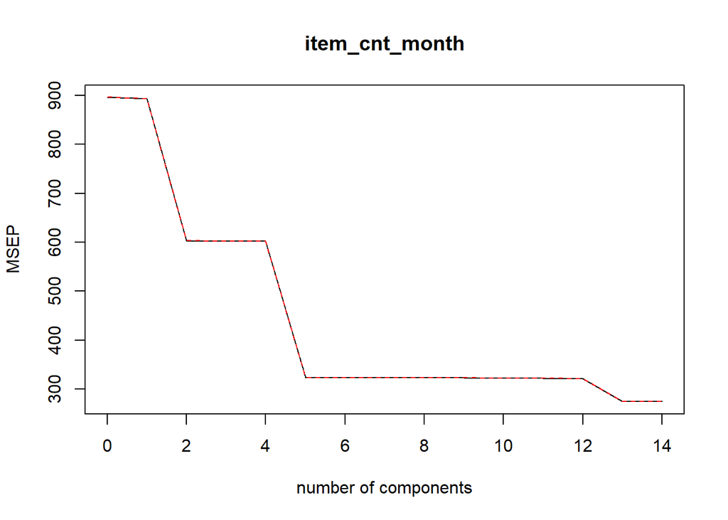

```r
validationplot(pcr.fit,val.type = 'MSEP')
```

```r
pcr.pred <- predict(pcr.fit, newdata = validate, ncomp = 5)
pcr.RMSE <- sqrt(mean((pcr.pred - validate$item_cnt_month)^2))
pcr.RMSE
```

```
## [1] 40.84496
```

6.3 PLS

```r
pls.fit <- plsr(item_cnt_month ~ ., data = train_train, validation = 'CV')
summary(pls.fit)
```

[output not shown]

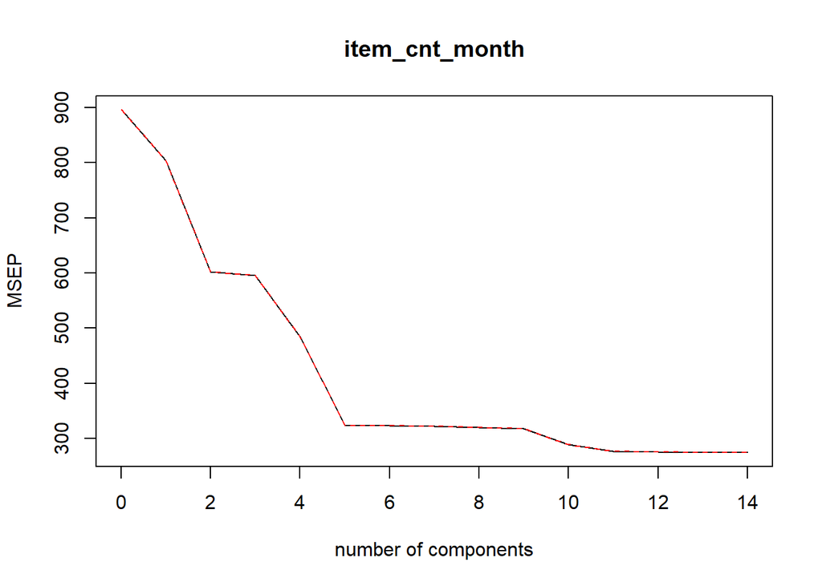

```r
validationplot(pls.fit,val.type = 'MSEP')
```

```r
pls.pred <- predict(pls.fit, newdata = validate, ncomp = 5)
pls.RMSE <- sqrt(mean((pls.pred - validate$item_cnt_month)^2))
pls.RMSE
```

```
## [1] 40.84406
```

6.4 Lasso

```r
x_train <-  model.matrix(item_cnt_month~.,train_train)[,-15]
y_train <-  train_train$item_cnt_month
x_validate <- model.matrix(item_cnt_month~.,validate)[,-15]

grid <- 10^seq(10, -2, length=100)
lasso.mod <- glmnet(x_train, y_train, alpha = 1,lambda = grid)
cv.out <- cv.glmnet(x_train, y_train, alpha = 1)
bestlam <- cv.out$lambda.min
lasso.pred <- predict(lasso.mod, s = bestlam, newx = x_validate)
lasso.RMSE <- sqrt(mean((lasso.pred - validate$item_cnt_month)^2))
lasso.RMSE
```

```
## [1] 44.96522
```

Lasso.RMSE = 44.965

6.5 Polynomial Regression

```r
poly.fit1 <- lm(item_cnt_month ~ shop_id + item_id + item_category_id + cnt_sum + I(cnt_sum^2),data = train_train)
poly.fit2 <- lm(item_cnt_month ~ shop_id + item_id + item_category_id + cnt_sum + I(cnt_sum^2) + I(cnt_sum^3),data = train_train)
poly.fit3 <- lm(item_cnt_month ~ poly(cnt_sum,2), data = train_train)
poly.fit4 <- lm(item_cnt_month ~ poly(cnt_sum,3), data = train_train)

poly.pred1 <-  predict(poly.fit1, newdata = validate)
poly.RMSE1 <- sqrt(mean((poly.pred1 - validate$item_cnt_month)^2))
poly.RMSE1
```

```
## [1] 40.42792
```

```r
poly.pred2 <-  predict(poly.fit2, newdata = validate)
poly.RMSE2 <- sqrt(mean((poly.pred2 - validate$item_cnt_month)^2))
poly.RMSE2
```

```
## [1] 40.56664
```

```r
poly.pred3 <-  predict(poly.fit3, newdata = validate)
poly.RMSE3 <- sqrt(mean((poly.pred3 - validate$item_cnt_month)^2))
poly.RMSE3
```

```
## [1] 40.48962
```

```r
poly.pred4 <-  predict(poly.fit4, newdata = validate)
poly.RMSE4 <- sqrt(mean((poly.pred4 - validate$item_cnt_month)^2))
poly.RMSE4
```

```
## [1] 40.62866
```

6.7 Step Function

```r
step.fit <- lm(item_cnt_month ~ cut(cnt_sum,4), data = train_train)
step.pred <-  predict(step.fit, newdata = validate)
step.RMSE <- sqrt(mean((step.pred - validate$item_cnt_month)^2))
step.RMSE
```

```
## [1] 41.09172
```

Step.RMSE = 41.091

6.6 Spline Line

```r
cntlims=range(matrix$cnt_sum)
cnt.grid=seq(from=cntlims[1],to=cntlims[2])
sp.fit=lm(item_cnt_month ~  bs(cnt_sum,knots=c(6,16,48)),data=train_train)
sp.pred=predict(sp.fit,newdata = validate,se=T)
sp.RMSE <- sqrt(mean((sp.pred$fit - validate$item_cnt_month)^2))
sp.RMSE
```

```
## [1] 40.60391
```

sp.RMSE = 40.604

6.7 Natural Spline Line

```r
nsp.fit <- lm(item_cnt_month ~  ns(cnt_sum,df=4),data=train_train)
nsp.pred <- predict(nsp.fit,newdata = validate,se=T)
nsp.RMSE <- sqrt(mean((nsp.pred$fit - validate$item_cnt_month)^2))
nsp.RMSE
```

```
## [1] 40.57669
```

6.8 XG boost

```r
trainMatrix <- sparse.model.matrix(item_cnt_month ~ shop_id + item_id + item_category_id + cnt_sum + cnt_sum_item + cnt_sum_shop + item_price + price_mean,
                                   data = train_train,
                                   contrasts.arg = c('shop_id', 'item_id'),
                                   sparse = TRUE, sci = FALSE)
#Create input for xgboost
trainDMatrix <- xgb.DMatrix(data = trainMatrix, label = train_train$item_cnt_month)

testMatrix <- sparse.model.matrix(item_cnt_month ~ shop_id + item_id + item_category_id + cnt_sum + cnt_sum_item + cnt_sum_shop + item_price + price_mean,
                                  data = validate,
                                  contrasts.arg = c('shop_id', 'item_id'),
                                  sparse = TRUE, sci = FALSE)
#Create input for xgboost
testDMatrix <- xgb.DMatrix(data = testMatrix, label = validate$item_cnt_month)

params <- list(booster = "gbtree",
               objective = "reg:linear",
               eval_metric = "rmse",
               eta = 0.5,       # no need more complexity
               min_child_weight = 5,
               #colsample_bytree = 1,
               gamma = 0.9,
               alpha = 1.0,
               max_depth = 10,    # no nead more depth
               subsample = 1,
               print_every_n = 20
               )

# parallel calculation
N_cpu = parallel::detectCores()

#Cross-validation
xgb.tab <- xgb.cv(data = trainDMatrix,
                  params = params,
                  maximize = FALSE, nrounds = 1000,
                  nthreads = N_cpu, nfold = 5, early_stopping_round = 10)
```

[output not shown]

```r
#Best Number of iterations
num_iterations = xgb.tab$best_iteration

# Train the model with optimized n_round
xgboost_tree <- xgb.train(data = trainDMatrix
                               , param = params
                               , maximize = TRUE, evaluation = 'rmse', nrounds = num_iterations)

# Visualize features importances
importance <- xgb.importance(feature_names = colnames(trainMatrix), model = xgboost_tree)
library(Ckmeans.1d.dp)
```

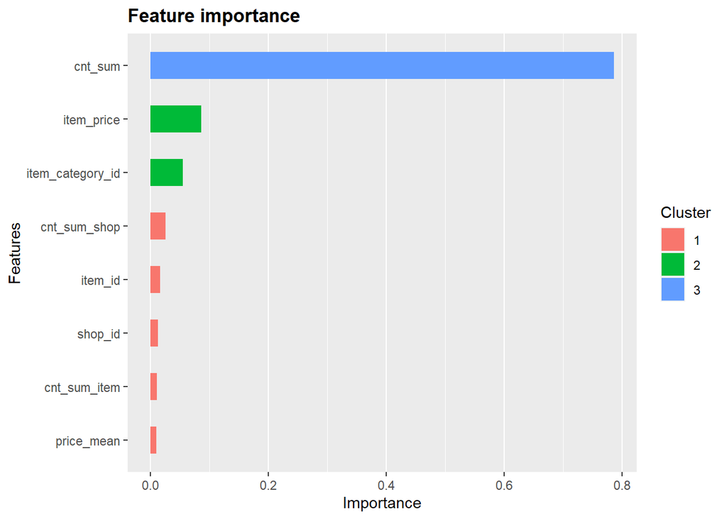

```r
xgb.ggplot.importance(importance_matrix = importance)
```

```r
# Prediction
pred_tree <- predict(xgboost_tree, testDMatrix)
XGboost.RMSE <- sqrt(mean((pred_tree - validate$item_cnt_month)^2))
XGboost.RMSE
```

```
## [1] 42.15081
```

7. Final Model Based all modeling discussion above, Linear Regression, PCR, PLS and Spline lines have low RMSE. Choose PCR as my final model. Consiered the feature importance ranking from XGboost, only keep cnt_sum, item_price, item_category_id and cnt_sum_shop in the final model.

Considered there are more than 10 features, use PCR model to select features rather than manual selection. The number of principal components, to incorporate in the model, is chosen by cross-validation (cv).Also, PCR is suitable when the data set contains highly correlated predictors as our model.

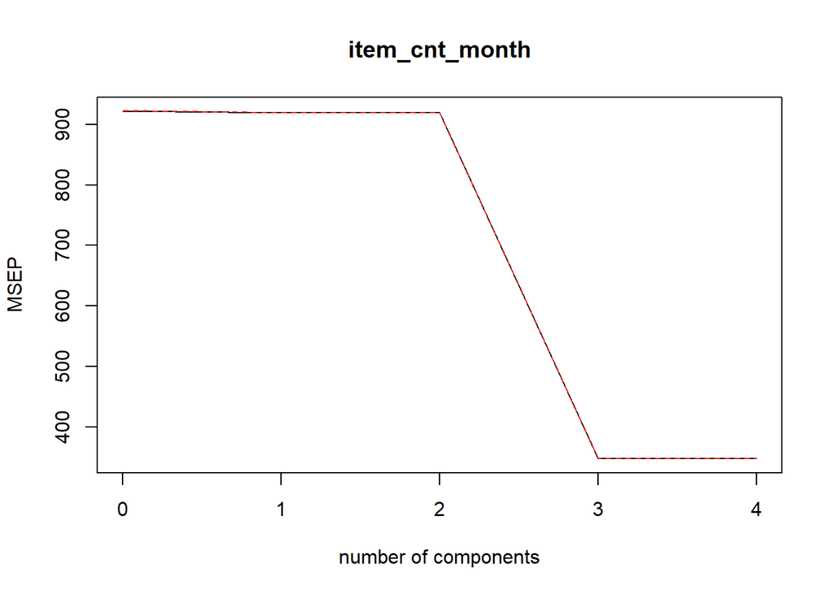

```r
train_final <- filter(matrix, date_block_num != 34)
test_final <- filter(matrix, date_block_num == 34)

final.fit <- pcr(item_cnt_month ~ cnt_sum + item_price + item_category_id + cnt_sum_shop, data = train_final, validation = 'CV')

validationplot(final.fit,val.type = 'MSEP')
```

```r
final.pred <- predict(final.fit, newdata = test_final, ncomp = 3)
```